# Exercise 3

Kwaku Peprah Adjei, Amir Ahmed

# Problem 1: Markov RF

In this exercise, we study problems relating to Mosaic random fields (RF). We have observations of seismic data, denoted by $\lbrace d(\vect x); \vect x \in L \rbrace$ ;$d(x) $, over a domain $\mathbf{D} \subset \mathbb{R}^2$. The seismic data is collected over a regular $(75 \times 75)$ grid $\mathbf{L}_\mathbf{D}$.

Moreover, we have observations of the lithology distribution $\{sand, shale\}$ in a geological comparable domain $\mathbf{D}_c \subset \mathbb{R}^2$. These are collected on a regular $(66 \times 66)$ grid $\mathbf{L}_{\mathbf{D}_c}$, which has the same spacing as $\mathbf{L}_\mathbf{D}$, over $\mathbf{D}_c$.

Let the underlying lithology distribution represented by a Mosaic RF be denoted by $\lbrace l(\vect x); \vect x \in L \rbrace ;l(\vect x) \in \{0,1 \}$. We want to identify the underlying lithology distribution over D, the underlying lithology of a point is either sand or shale, $\lbrace 1, 0 \rbrace$ respectively.

## Problem 1a)

We start by looking at $L_d$. Let the seismic data collection procedure follow the following likelihood model:
$$\left[d_i | \vect l \right] = \begin{cases}
0.02 + U_i \text{ if sand, } l_i = 0 \\
0.08 + U_i \text{ if shale, } l_i = 1
\end{cases}$$
$i = 1, 2, \dots, n$. With $U_i$ being identically independently distributed $U_i \sim N(0, 0.06^2)$. This would make each observation point $d_i$ conditionally independent on $\vect l$. That will say:
$$\begin{equation}
p(d_i | \vect l) = p(d_i | l_i) = \phi(d_i ; \mu = 0.02 + 0.06l_i, \sigma^2 = 0.06^2)
\end{equation}$$
Where $\phi$ is the pdf of the normal distribution. As all observations are independent we thus have:
$$\begin{equation}\label{eq:cond_prob}
p(\vect d | \vect l) = \prod_{i=1}^{n}p(d_i | l_i) = \prod_{i=1}^{n} \phi(d_i ; \mu = 0.02 + 0.06l_i, \sigma^2 = 0.06^2)
\end{equation}$$

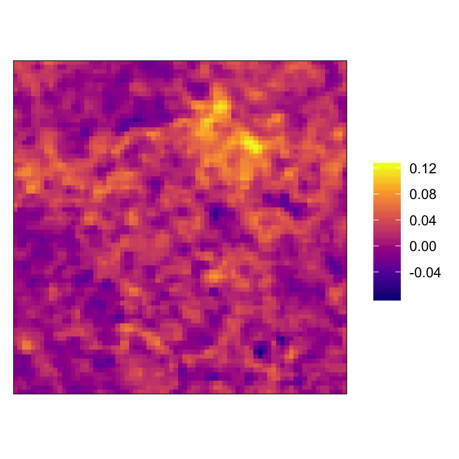

Display of seismic data $L_D$.

We display the observations from $L_D$ as a map in Figure , there seems to be one large gathering where $d(\vect x)$ takes on relatively large values, there also seems to be some smaller gatherings of large $d(\vect x)$ in areas centered around the large one.

We now consider a uniform, independence prior model on $\vect l$. That will say:
$$\begin{equation}
p(\vect l) = const
\end{equation}$$
We note that since the prior is constant we have:
$$\begin{equation}
p(\vect l | \vect d) \propto p(\vect d | \vect l)
\end{equation}$$

We get the following posterior model using bayes law and the law of total probability:
$$\begin{equation}
p(\vect l | \vect d) = \dfrac{p(\vect d | \vect l)}{\sum_{\vect l \in \mathbb{L}^n}p(\vect d | \vect l)}
\end{equation}$$
Inserting from we get:
$$\begin{equation}
p(\vect l | \vect d) = \dfrac{ \prod_{i=1}^{n} \phi(d_i ; \mu = 0.02 + 0.06l_i, \sigma^2 = 0.06^2)}{\sum_{\vect l' \in \mathbb{L}^n} \prod_{i=1}^{n} \phi(d_i ; \mu = 0.02 + 0.06l_i', \sigma^2 = 0.06^2)}
\end{equation}$$

Where $\mathbb{L}^n$ is the n-dimensional space representing all possible values which $l$ can take.

As the prior is independent each point would also be conditional independent, for each point we thus get the following. Let:
$$\begin{equation}
\begin{split}
p_i &= p(l_i = 1 | d_i)
\\ &= \dfrac{p(d_i | l_i = 1)}{p(d_i | l_i = 0) + p(d_i | l_i = 1)}
\\ &= \dfrac{\phi(d_i ; \mu = 0.08, \sigma^2 = 0.06^2)}{\phi(d_i ; \mu = 0.02, \sigma^2 = 0.06^2) + \phi(d_i ; \mu = 0.08, \sigma^2 = 0.06^2)}
\end{split}
\end{equation}$$
As each point either is sand or shale we get:
$$\begin{equation}
1 - p_i = p(l_i = 0 | d_i)
\end{equation}$$
We recognize this conditioned model as something Bernoulli-distributed with probability $p_i$.

We thus have:
$$\begin{equation}
E(l_i | d_i) = p_i
\end{equation}$$
and
$$\begin{equation} \label{eq:var}
Var(l_i | d_i) = p_i(1-p_i)
\end{equation}$$

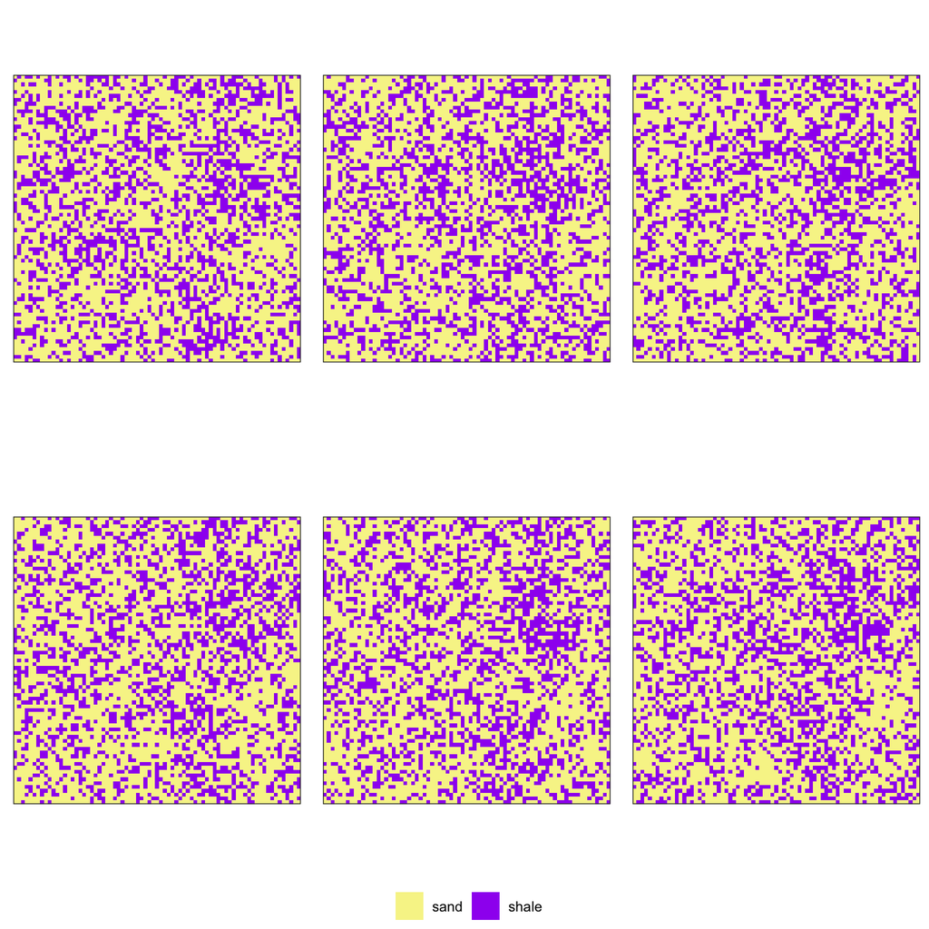

Display of six posterior realizations of $L_D$.

We simulate 6 trials with the data and display the results in Figure .

The maximum marginal posterior predictor ($MMAP\lbrace \vect l | \vect d \rbrace$) is defined as:
$$\begin{equation} \label{eq:mmap}
MMAP\lbrace \vect l | \vect d \rbrace = \vect{\hat l} = argmax_{\vect l \in \mathbb{L}^n}\lbrace p(\vect l | \vect d)\rbrace
\end{equation}$$

Due to the conditional independence of the points we see:
$$\begin{equation}
\hat l_i = \begin{cases}
0, \text{ if } p_i < 0.5 \\
1, \text{ if } p_i \geq 0.5
\end{cases}
\end{equation}$$
is a MMAP solution.

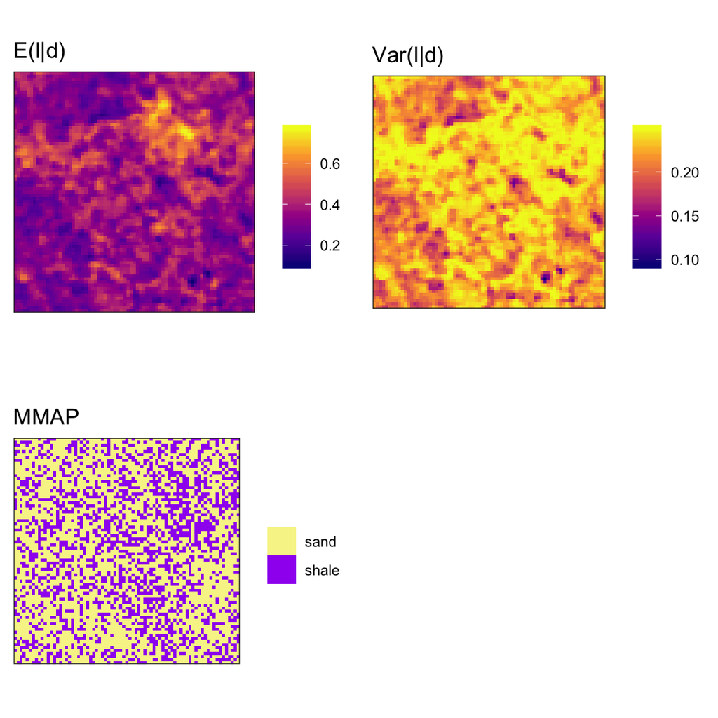

Plot of MMAP, expected values and variance with uniform prior

## Problem 1c)

Now consider a Markov RF prior model for $\lbrace l(\vect x); \vect x \in L_D \rbrace$. Represented by the n-vector $\vect l$ with the clique system $\vect c_L$ consisting of two closest neighbors on the grid $L_D$.

The corresponding Gibbs formulation is:
$$\begin{equation}
\begin{split}
p(\vect l) = const \times \prod_{\vect c \in \vect c_L} v_{1l}(l_i, i \in \vect c) &= const \times \prod_{<i, j>\in L_D} \beta^{I(l_i = l_j)} \\
&= const \times \beta^{\sum_{<i, j>\in L_D} I(l_i = l_j)}
\end{split}
\end{equation}$$
With $<i, j> \in L_d$ defining the set of two closest neighbors on the grid $L_D$.

Want to find expressions for the posterior models and want to specify the Markov formulation for the Markov RF.

Want to find the Markov formulation for the Markov RF. First see:
$$\begin{equation}
p(l_i | \vect l_{-i}) = \dfrac{p(\vect l)}{\sum_{l_i' \in \mathbb{L}} p(l_i', \vect l_{-i})} = \dfrac{p(\vect l)}{p(l_i = 1, \vect l_{-i}) +p(l_i = 0, \vect l_{-i})}
\end{equation}$$
This reduces to:
$$\begin{equation}
p(l_i | \vect l_{-i}) = p(l_i | l_j, j \in n_i)
\end{equation}$$

We note that the joint distribution is given by:
$$\begin{equation}
\begin{split}
p(\vect d, \vect l) &= p(\vect d | \vect l)p(\vect l)
\\ &= const \times \prod_{i=1}^{n}p(d_i | l_i) \prod_{\vect c \in \vect c_L} v_{1l}(l_i, i \in \vect c)
\\ &= const \times \prod_{i=1}^{n} \phi(d_i ; \mu = 0.02 + 0.06l_i, \sigma^2 = 0.06^2) \prod_{<i, j>\in L_D} \beta^{I(l_i = l_j)}
\end{split}
\end{equation}$$

We input the above into the following:
$$\begin{equation}
p(\vect l | \vect d) = \dfrac{p(\vect l, \vect d)}{p(\vect d)} = const \times \prod_{i=1}^{n} \phi(d_i ; \mu = 0.02 + 0.06l_i, \sigma^2 = 0.06^2) \prod_{<i, j>\in L_D} \beta^{I(l_i = l_j)}
\end{equation}$$
Also:
$$\begin{equation}
\begin{split}
p(l_i, \vect d | \vect l_{-i}) &= p(\vect d | \vect l)p(l_i | \vect l_{-i}) \\ &= p(\vect d | \vect l)p(l_i | \vect l_{-i}) \\
&= \dfrac{p(\vect l)}{p(l_i = 1, \vect l_{-i}) +p(l_i = 0, \vect l_{-i})} \prod_{i=1}^{n} \phi(d_i ; \mu = 0.02 + 0.06l_i, \sigma^2 = 0.06^2)
\end{split}
\end{equation}$$
Let $n_i$ be the neighborhood around the ith node. Then have:
$$\begin{equation}
p(l_i, \vect d | \vect l_{-i}) = \dfrac{\prod_{l_j \in n_i}\beta^{I(l_i = l_j)}}{\prod_{l_j \in n_i}\beta^{I(0 = l_j)} + \prod_{l_j \in n_i}\beta^{I(1 = l_j)}} \prod_{i=1}^{n} \phi(d_i ; \mu = 0.02 + 0.06l_i, \sigma^2 = 0.06^2)
\end{equation}$$

Now want to develop expressions for the posterior model $p(l_i | \vect d, \vect l_{-i})$ have:
$$\begin{equation}
\begin{split}
p(l_i | \vect d, \vect l_{-i}) &= p(l_i | d_i, l_{j} ; j \in n_i)
\\ &= \dfrac{p(l_i, d_i, l_j ; j \in n_i)}{p(d_i, l_j ; j \in n_i)}
\\ &= \dfrac{p(d_i | l_i)\prod_{l_j \in n_i}\beta^{I(l_i = l_j)}}{\phi(d_i|\mu = 0.02, \sigma^2 = 0.06^2)\prod_{l_j \in n_i}\beta^{I(l_j = 0)} + \phi(d_i|\mu = 0.08, \sigma^2 = 0.06^2)\prod_{l_j \in n_i}\beta^{I(l_j = 1)}}
\end{split}
\end{equation}$$

as the Markov formulation.

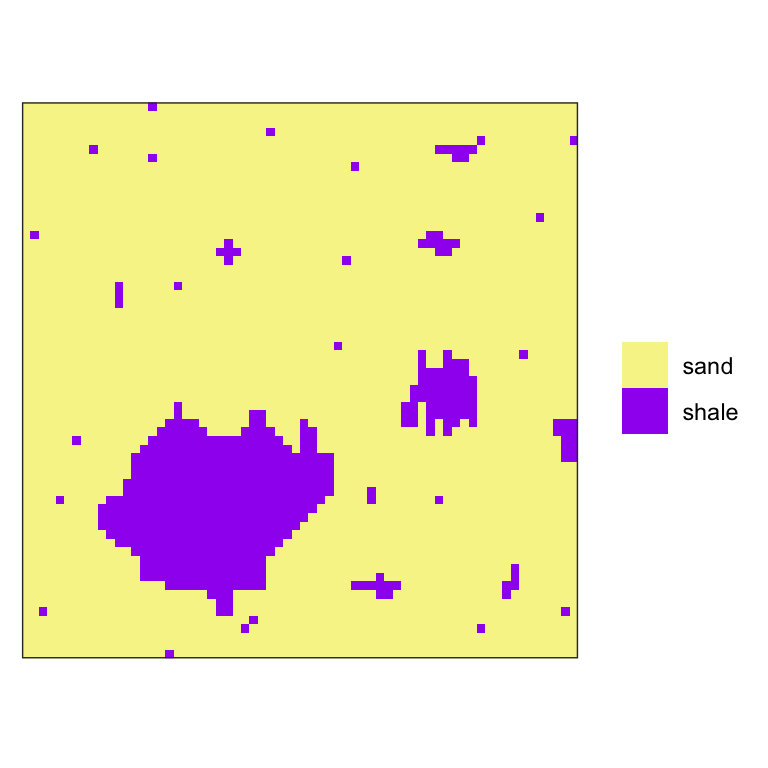

Display of observed data in $D_c$

We now display the observations in $D_c$ in Figure .

Now want to use these observations to estimate $\beta$ by a maximum pseudo-likelihood procedure. In a optimal solution we would use the assumed $p(\vect l)$ distribution to do this, however we would need $2^n$ calculations to evaluate the normalizing constant, which in our case is infeasible. We rather use the Markov formulation to create an approximation. (here $\vect d \in \mathbb{L}^n$)

$$\begin{equation} \label{eq:ising}
p(\vect d | \beta ) \approx \hat p(\vect d | \beta) = const \times \prod_{i = 1}^{n}\sum_{\lbrace l_i', l_j' | l_j' \in n_i \rbrace \in L } \prod_{j = i, j \in n_i}p(d_j | l_j')p(l_i'|l_j')
\end{equation}$$

As we assume the observations to $\vect l$ from $D_c$ be exact the model reduces as:
$$\begin{equation}
p(d_i | l_i') \rightarrow \delta_{d_i}(l_i') = \begin{cases}
1, l_i' = l_i \\
0, \text{ else}
\end{cases}
\end{equation}$$

This reduces to:
$$\begin{equation}
\hat p(\vect d | \beta) \propto \prod_{i = 1}^n p(d_i|l_j; j \in n_i; \beta) = \prod_{i=1}^{n}\dfrac{\beta^{\sum_{j \in n_i}I(l_i = l_j)}}{\beta^{\sum_{j \in n_i}I(0 = l_j)} + \beta^{\sum_{j \in n_i}I(1 = l_j)}}
\end{equation}$$

A good estimation of $\beta$ would be to maximize the above giving:
$$\begin{equation}
\hat \beta = \text{argmax}_\beta \sum_{i=1}^{n} \left\{ \left( \sum_{j \in n_i}I(l_i = l_j)\right)\log\beta - \log\left(\beta^{\sum_{j \in n_i}I(0 = l_j)} + \beta^{\sum_{j \in n_i}I(1 = l_j)}\right) \right\}
\end{equation}$$

Using the Optim function in R this value can be “easily” found. Implementing the function and running we get that $\hat \beta \approx 3.64$.

We can use the information we learned from $D_c$ and apply it to out model on $L_d$ as their lithology is comparable.

Focus is on realizations from $p(\vect l|\vect d)$, with related predictions $E(\vect l|\vect d)$, variances in the diagonal terms of $Var(\vect l|\vect d)$, and alternative predictions $MMAP(\vect l|\vect d)$.

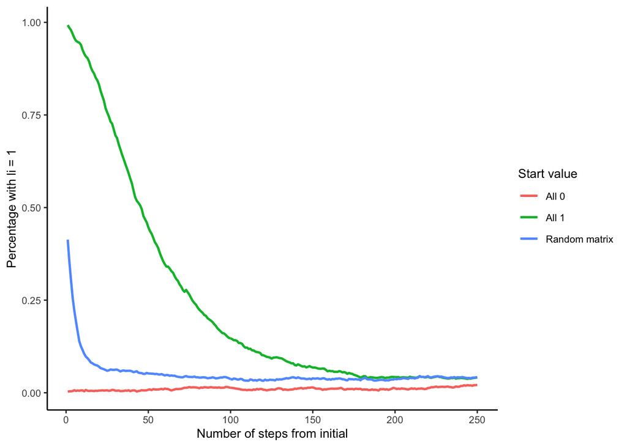

Display of the proportion of shale using different initial values after 250 iterations.

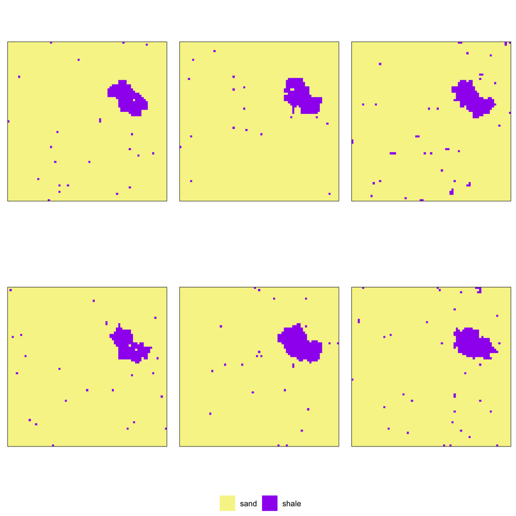

Six realisations from the MCMC/Gibbs algorithm.

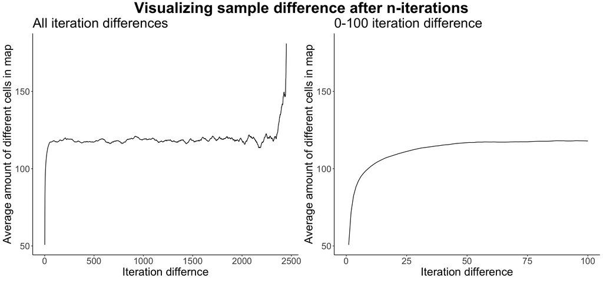

Average sample difference, 2450 samples, to check independence

We thus decide on taking each 50-th step as a independent sample.

An alternative to this method could i.e. be based on corrolation.

Using our independent samples we have following estimator:
$$\begin{equation}
E(l_i|d_i) = p_i = \dfrac{1}{m}\sum_{j=1}^ml_i^j
\end{equation}$$

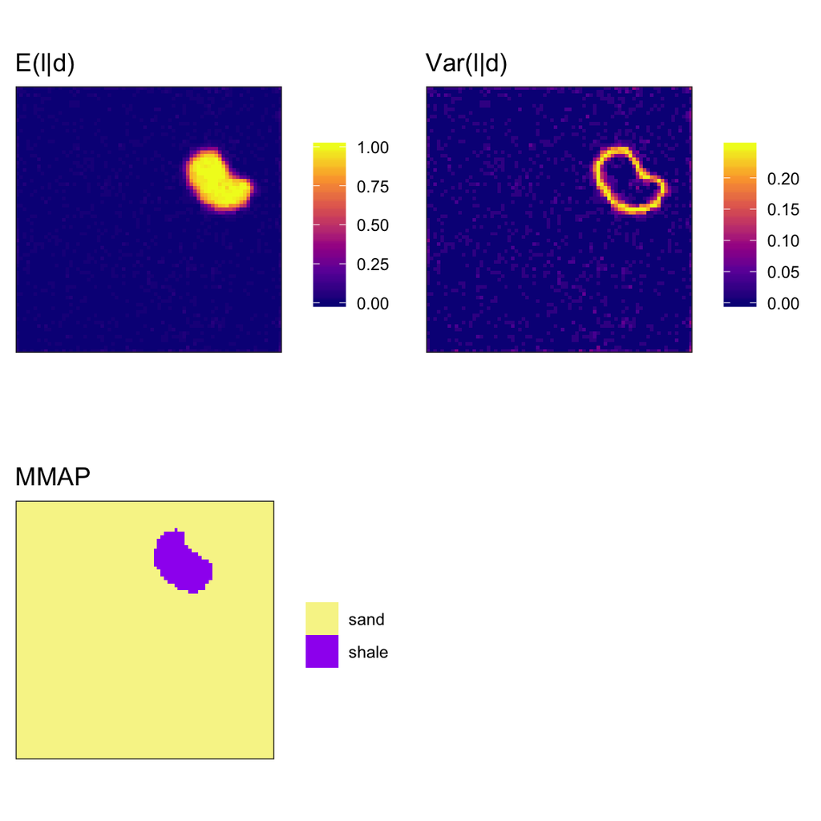

Estimators from independent gibbs sample

Where $m$ is the number of independent samples, and $l_i^j$ is the $i$-th cell in the $j$-th sample. Estimators for variancce and MMAP are and respectively. The results hare shown in Figure . Compared with the model with the constant prior this model gives a result with a solid body, in the top-right part of the plot. Variance is close to zero, expect at the edges of the solid shale area. The MMAP reflects the expected value, and only shows one connected area where one expect shale.

## Problem 1d)

Comparing the two methods, the first in 1b) with a uniform prior and the Markov RF in 1c), the Markov RF seems to produce less noise and samples from it seems much more stable and shows much less variance. Samples from the Markov RF seems match what is observed in $D_c$ much better than 1a). Although it takes much more time to implement and run, the Markov RF produces much better results than its competitor.

On the other hand, 1c) might be a bit too strict on what is classified as a shale-area, compared to $D_c$ there seems to be few outlier shale fields, and small shale fields. A possibility to improve on this would be to manually alter the $\beta$ estiamte somewhat.

In both cases we also note that the MMAP gave satisfying results.